# 8. Intractability III

8. Intractability III

WU Xiaokun 吴晓堃

xkun.wu [at] gmail

2021/11/26

## Coping with NP-completeness

**Q**. Suppose I need to solve an NP-hard problem. What should I do?

**A**. Sacrifice one of three desired features.

- 1. Solve *arbitrary instances* of the problem.
- 2. Solve problem to *optimality*.
- 3. Solve problem in *polynomial time*.

**Coping strategies**.

- 1. Design algorithms for *special cases* of the problem.
- 2. Design *approximation algorithms* or *heuristics*.
- 3. Design algorithms that may take *exponential time*.

# Special cases: trees

## Independent set on trees

**Independent set on trees**. Given a *tree*, find a max-cardinality subset of nodes that no two are adjacent.

**Fact**. A tree has at least one leaf node (degree = 1).

**Key observation**. If node $v$ is a leaf, there exists a max-cardinality independent set containing $v$.

**Pf**. [exchange argument]

- Consider a max-cardinality independent set $S$.
- If $v \in S$, we’re done.
- Otherwise, let $(u, v)$ denote the lone edge incident to $v$.
  - if $u \notin S$ and $v \notin S$, then $S \cup \{ v \}$ is independent $\Rightarrow S$ not maximum
  - if $u \in S$ and $v \notin S$, then $S \cup \{ v \} - \{ u \}$ is independent

## IS on trees: greedy

`INDEPENDENT-SET-IN-A-FOREST`($F$)

1. $S = \emptyset$;
2. WHILE ($F$ has at least 1 edge)
   1. Let $v$ be a leaf node and let $(u, v)$ be the lone edge incident to $v$;
   2. $S = S \cup \{ v \}$;
   3. $F = F - \{ u, v \}$;
3. RETURN $S \cup { \text{nodes remaining in}\ F }$;

**Theorem**. The greedy algorithm finds a max-cardinality independent set in forests (and hence trees).

**Remark**. Can implement in $O(n)$ time by maintaining nodes of degree 1.

## Demo: greedy for IS on trees

## Quiz: greedy for IS

How might the greedy algorithm fail if the graph is not a tree/forest?

**A**. Might get stuck.  
**B**. Might take exponential time.  
**C**. Might produce a suboptimal independent set.  
**D**. Any of the above.

A. the algorithm relies on leave nodes.

## Weighted independent set on trees

**Weighted independent set on trees**. Given a tree and node weights $w_v \ge 0$, find an independent set $S$ that maximizes $\sum_{v \in S} w_v$.

**Greedy algorithm can fail spectacularly**.

- hint: when $w_v$ is huge.

## Weighted independent set on trees

**Weighted independent set on trees**. Given a tree and node weights $w_v \ge 0$, find an independent set $S$ that maximizes $\sum_{v \in S} w_v$.

**Dynamic-programming solution**. Root tree at some node, say $r$.

- $OPT_{in} (u)$ = max-weight IS in subtree rooted at $u$, *including* $u$.
- $OPT_{out} (u)$ = max-weight IS in subtree rooted at $u$, *excluding* $u$.
- Goal: $\max \{ OPT_{in} (r), OPT_{out} (r) \}$.

**Bellman equation**.

$$\begin{aligned}
OPT_{in} (u) & = w_u + \sum_{v \in children(u)} OPT_{out} (v) \\
OPT_{out} (u) & = \sum_{v \in children(u)} \max \{ OPT_{in} (v),
OPT_{out} (v) \} \\
\end{aligned}$$

## Quiz: DP for Weighted IS

In which order to solve the subproblems?

**A**. Preorder.  
**B**. Postorder.  
**C**. Level order.  
**D**. Any of the above.

## Weighted IS on trees: DP

`WEIGHTED-INDEPENDENT-SET-IN-A-TREE` ($T$)

1. Root the tree $T$ at any node $r$;
2. $S = \emptyset$;
3. FOREACH (node $u$ of $T$ in postorder/topological order)
   1. IF ($u$ is a leaf node)
      1. $M_{in}[u] = w_u$; $M_{out}[u] = 0$;
   2. ELSE
      1. $M_{in}[u] = w_u + \sum_{v \in children(u)} M_{out}[v]$;
      2. $M_{out}[u] = \sum_{v \in children(u)} \max \{ M_{in}[v], M_{out}[v] \}$;
4. RETURN $\max \{ M_{in}[r], M_{out}[r] \}$;

**Theorem**. The DP algorithm computes max weight of an independent set in a tree in $O(n)$ time.

**Note**: can also find independent set itself (not just value)

## NP-hard problems on trees: intuition

**Independent set on trees**. Tractable because we can find a node that *breaks the communication* among the subproblems in different subtrees.

# Special cases: planarity

## Planarity

**Def**. A graph is **planar** if it can be embedded in the plane in such a way that no two edges cross.

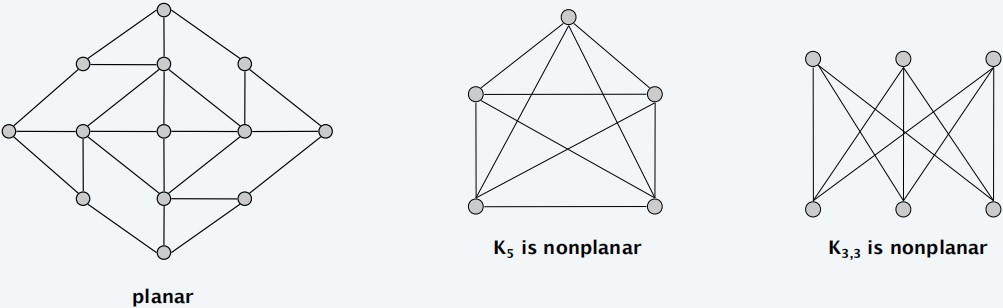

**Applications**. VLSI circuit design, computer graphics, etc.

## Planarity testing

**Theorem**. [Hopcroft-Tarjan 1974] There exists an $O(n)$ time algorithm to determine whether a graph is planar.

## Problems on planar graphs

**Fact 0**. Many graph problems can be solved faster in planar graphs.  
**Ex**. Shortest paths, max flow, MST, matchings, etc.

**Fact 1**. Some NP-complete problems become tractable in planar graphs.  
**Ex**. MAX-CUT, ISING, CLIQUE, GRAPH-ISOMORPHISM, 4-COLOR, etc.

**Fact 2**. Other NP-complete problems become easier in planar graphs.  
**Ex**. INDEPENDENT-SET, VERTEX-COVER, TSP, STEINER-TREE, etc.

## Planar graph 3-colorability

**PLANAR-3-COLOR**. Given a planar graph, can it be colored using 3 colors so that no two adjacent nodes have the same color?

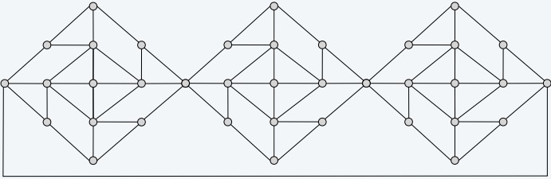

## Planar map 3-colorability

**PLANAR-MAP-3-COLOR**. Given a planar map, can it be colored using 3 colors so that no two adjacent regions have the same color?

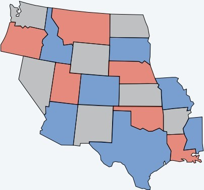

## Planar map 3-colorability

**PLANAR-MAP-3-COLOR**. Given a planar map, can it be colored using 3 colors so that no two adjacent regions have the same color?

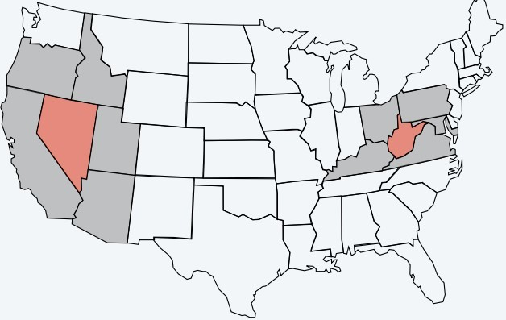

## Theorem: $\equiv_P$

**Theorem**. PLANAR-3-COLOR $\equiv_P$ PLANAR-MAP-3-COLOR.  
**Pf sketch**.

- Nodes correspond to regions.
- Two nodes are adjacent iff they share a nontrivial border.

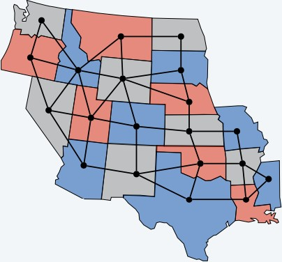

## PLANAR-3-COLOR $\in$ NP-complete

**Theorem**. PLANAR-3-COLOR $\in$ NP-complete.  
**Pf**.

- Easy to see that PLANAR-3-COLOR $\in$ NP.
- We show 3-COLOR $\le_P$ PLANAR-3-COLOR.
- Given 3-COLOR instance $G$, we construct an instance of PLANAR-3-COLOR that is 3-colorable iff $G$ is 3-colorable.

## PLANAR-3-COLOR $\in$ NP-complete: gadget

**Lemma**. $W$ is a planar graph such that:

- In any 3-coloring of $W$, opposite corners have the same color.
- Any assignment of colors to the corners in which opposite corners have the same color extends to a 3-coloring of $W$.

**Pf**. The only 3-colorings (modulo permutations) of $W$ are shown below.

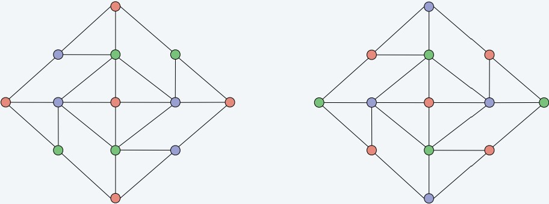

## PLANAR-3-COLOR $\in$ NP-complete: lemma

**Construction**. Given instance $G$ of 3-COLOR, draw $G$ in plane, letting edges cross. Form planar $G'$ by replacing each edge crossing with planar gadget $W$.

**Lemma**. $G$ is 3-colorable iff $G'$ is 3-colorable.

- In any 3-coloring of $W$, $a \ne a'$ and $b \ne b'$.
- If $a \ne a'$ and $b \ne b'$ then can extend to a 3-coloring of $W$.

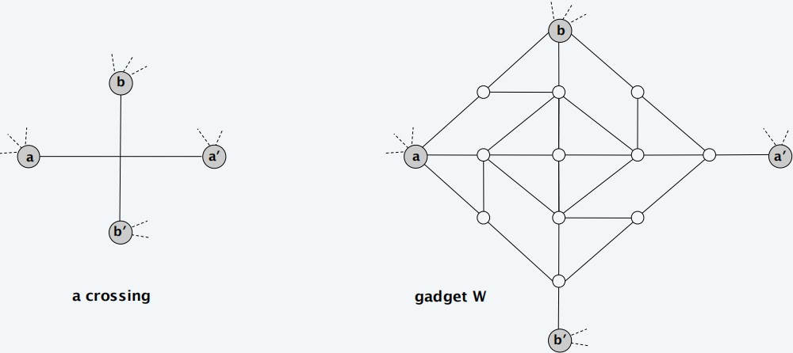

## PLANAR-3-COLOR $\in$ NP-complete: lemma

**Construction**. Given instance $G$ of 3-COLOR, draw $G$ in plane, letting edges cross. Form planar $G'$ by replacing each edge crossing with planar gadget $W$.

**Lemma**. $G$ is 3-colorable iff $G'$ is 3-colorable.

- In any 3-coloring of $W$, $a \ne a'$ and $b \ne b'$.
- If $a \ne a'$ and $b \ne b'$ then can extend to a 3-coloring of $W$.

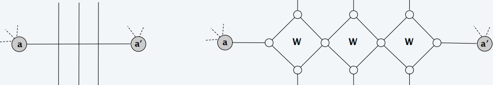

## Planar map $k$-colorability

**Theorem**. [Appel-Haken 1976] Every planar map is 4-colorable.

- Resolved century-old open problem.
- Used 50 days of computer time to deal with many special cases.
- First major theorem to be proved using computer.

[figure not shown]

**Remarks**.

- Appel-Haken yields $O(n^4)$ algorithm to 4-color of a planar map.
- Best known: $O(n^2)$ to 4-color; $O(n)$ to 5-color.
- Determining whether 3 colors suffice is NP-complete.

## NP-hard: Poly-time special cases

**Trees**. VERTEX-COVER, INDEPENDENT-SET, LONGEST-PATH, GRAPH-ISOMORPHISM, etc.

**Bipartite graphs**. VERTEX-COVER, INDEPENDENT-SET, 3-COLOR, EDGE-COLOR, etc.

**Planar graphs**. MAX-CUT, ISING, CLIQUE, GRAPH-ISOMORPHISM, 4-COLOR, etc.

**Bounded treewidth**. HAM-CYCLE, INDEPENDENT-SET, GRAPH-ISOMORPHISM, etc.

**Small integers**. SUBSET-SUM, KNAPSACK, PARTITION, etc.

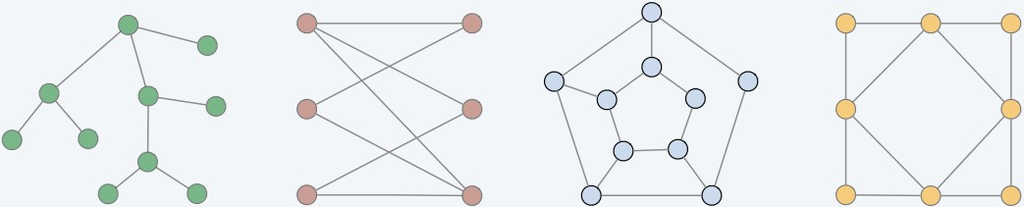

# Approximation algorithms: vertex cover

## Approximation algorithms

**$\rho$-approximation algorithm**.

- Runs in polynomial time.
- Applies to arbitrary instances of the problem.
- Guaranteed to find a solution within ratio $\rho$ of true optimum.

**Ex**. Given a graph $G$, can find a vertex cover that uses $\le 2 \cdot OPT(G)$ vertices in $O(m + n)$ time.

**Challenge**. Need to prove a solution’s value is close to optimum value, without even knowing what optimum value is!

## Vertex cover

**VERTEX-COVER**. Given a graph $G = (V, E)$, find a min-size vertex cover.

- for each edge $(u, v) \in E$: either $u \in S$, $v \in S$, or both

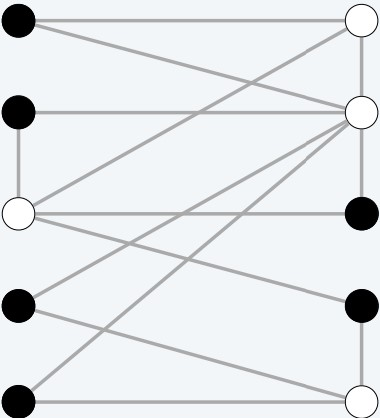

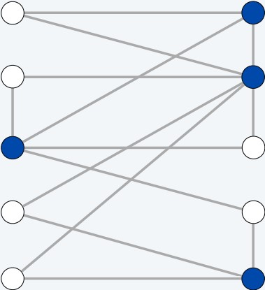

## Vertex cover: greedy

`GREEDY-VERTEX-COVER`($G$)

1. $S = \emptyset$; $E' = E$;
2. WHILE ($E' \ne \emptyset$)
   1. Let $(u, v) ∈ E'$ be an arbitrary edge;
   2. $M = M \cup \{(u, v)\}$;
   3. $S = S \cup \{u\} \cup \{v\}$;
   4. Delete from $E'$ all edges incident to either $u$ or $v$;
3. RETURN $S$;

**Running time**. Can be implemented in $O(m + n)$ time.

## Demo: Greedy Vertex-Cover

## Quiz: Vertex cover

Given a graph $G$, let $M$ be any matching and let $S$ be any vertex cover. Which of the following must be true?

**A**. $|M | \le |S |$  
**B**. $|S | \le |M |$  
**C**. $|S | = |M |$  
**D**. None of the above.

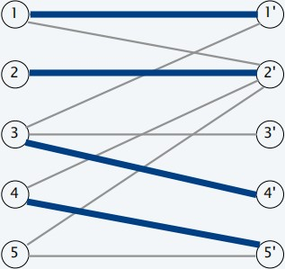

A. if two nodes not matched, then they are not covered and conected, contra to cover; when covering nodes are matched to each other, strictly less.

**Pf**. Each vertex can cover at most one edge in any matching.

## Vertex cover: 2-approximation

**Theorem**. Let $S^\ast$ be a minimum vertex cover. Then, greedy algorithm computes a vertex cover $S$ with $|S | \le 2 |S^\ast |$ (ie. **2-approximation** algorithm).  
**Pf**.

- $S$ is a vertex cover.
  - (delete edge only after it’s already covered)
- $M$ is a matching.
  - (when $(u, v)$ added to $M$, all edges incident to either $u$ or $v$ are deleted)
- $|S | = 2 |M | \le 2 |S^\ast |$.
  - by design of algorithm, and “weak duality”

**Corollary**. Let $M^\ast$ be a maximum matching. Then, greedy algorithm computes a matching $M$ with $|M | ≥ ½ |M^\ast |$.  
**Pf**. $|M | = ½ |S | ≥ ½ |M^\ast |$.

## Vertex cover inapproximability

**Theorem**. [Dinur-Safra 2004] If $P \ne NP$, then no $\rho$-approximation for VERTEX-COVER for any $\rho < 1.3606$.

**Open research problem**. Close the gap $(1.3606, 2)$.

**Conjecture**. no $\rho$-approximation for VERTEX-COVER for any $\rho < 2$.

# Approximation algorithms: knapsack

## Knapsack problem

**Knapsack problem**.

- Given $n$ objects and a knapsack.
- Item $i$ has value $v_i > 0$ and weighs $w_i > 0$.
- Knapsack has *weight limit* $W$.
- Goal: fill knapsack so as to *maximize total value*.

**Ex**: $\{ 3, 4 \}$ has value $40$.

| item | value | weight |
| --- | --- | --- |
| 1 | 1 | 1 |
| 2 | 6 | 2 |
| 3 | 18 | 5 |
| 4 | 22 | 6 |
| 5 | 28 | 7 |

## Knapsack is NP-complete

**SUBSET-SUM**. Given a set $X$, values $u_i ≥ 0$, and an integer $U$, is there a subset $S \subseteq X$ whose elements sum to exactly $U$?

## Knapsack problem: DP I

**Def**. $OPT(i, w)$ = max value subset of items $1, .., i$ with *weight* limit $w$.

**Case 1**. $OPT$ does not select item $i$.

- $OPT$ selects best of $1, .., i - 1$ using up to weight limit $w$.

**Case 2**. $OPT$ selects item $i$.

- New weight limit = $w - w_i$.
- $OPT$ selects best of $1, .., i - 1$ using up to weight limit $w - w_i$.

$$OPT(i, w) = \left\{ \begin{array}{ll}
0 & \text{if}\ i = 0 \\
OPT(i-1, w) & \text{if}\ w_i > w \\
\max \{ OPT(i-1, w), v_i + OPT(i-1, w-w_i) \} & \text{otherwise} \\
\end{array}\right.$$

**Theorem**. Computes the optimal value in $O(n W)$ time.

- Not polynomial in input size.
- Polynomial in input size if weights are small integers.

## Knapsack problem: DP II

**Def**. $OPT(i, v)$ = min weight of a knapsack for which we can obtain a solution of *value* $\ge v$ using a subset of items $1, .., i$.

**Note**. Optimal value is the largest value $v$ such that $OPT(n, v) \le W$.

**Case 1**. $OPT$ does not select item $i$.

- $OPT$ selects best of $1, .., i - 1$ that achieves value $\ge v$.

**Case 2**. $OPT$ selects item $i$.

- Consumes weight $w_i$, need to achieve value $\ge v - v_i$.
- $OPT$ selects best of $1, .., i - 1$ that achieves value $\ge v - v_i$.

$$OPT(i, v) = \left\{ \begin{array}{ll}
0 & \text{if}\ v \le 0 \\
\infty & \text{if}\ i = 0\ \text{and}\ v > 0 \\
\min \{ OPT(i-1, v), w_i + OPT(i-1, v-v_i) \} & \text{otherwise} \\
\end{array}\right.$$

## Knapsack problem: DP II (cont.)

**Theorem**. Dynamic programming algorithm II computes the optimal value in $O(n^2 v_{max})$ time, where $v_{max}$ is the maximum of any value.  
**Pf**.

**Remark 1**. Not polynomial in input size! (pseudo-polynomial)  
**Remark 2**. Polynomial time if values are small integers.

## Poly-time approximation scheme

**Intuition for approximation algorithm**.

- Round all values up to lie in smaller range.
- Run dynamic programming algorithm II on rounded/scaled instance.
- Return optimal items in rounded instance.

| item | value | weight |
| --- | --- | --- |
| 1 | 934221 | 1 |
| 2 | 5956342 | 2 |
| 3 | 17810013 | 5 |
| 4 | 21217800 | 6 |
| 5 | 27343199 | 7 |

| item | value | weight |
| --- | --- | --- |
| 1 | 1 | 1 |
| 2 | 6 | 2 |
| 3 | 18 | 5 |
| 4 | 22 | 6 |
| 5 | 28 | 7 |

## Poly-time approximation scheme

**Round up all values**:

- $0 < \epsilon \le 1$ = precision parameter.
- $v_{max}$ = largest value in original instance.
- $\theta$ = scaling factor = $\epsilon v_{max} / 2n$.

$$\bar{v_i} = \lceil \frac{v_i}{\theta} \rceil \theta,
\hat{v_i} = \lceil \frac{v_i}{\theta} \rceil$$

**Observation**. Optimal solutions to problem with $\bar{v}$ are equivalent to optimal solutions to problem with $\hat{v}$.

**Intuition**. $\bar{v}$ close to $v$ so optimal solution using $\bar{v}$ is nearly optimal; $\hat{v}$ small and integral so dynamic programming algorithm II is fast.

## Poly-time approximation scheme

**Theorem**. If $S$ is solution found by rounding algorithm and $S^\ast$ is any other feasible solution satisfying weight constraint, then $(1 + \epsilon) \sum_{i \in S} v_i \ge \sum_{i \in S^\ast} v_i$.

**Pf**.

$$\begin{aligned}
\sum_{i \in S^\ast} v_i & \le \sum_{i \in S^\ast} \bar{v_i}
&& \text{round up}\\
& \le \sum_{i \in S} \bar{v_i} && \text{optimality} \\
& \le \sum_{i \in S} (v_i + \theta) && \text{rounding gap}
\\
& \le \sum_{i \in S} v_i + n\theta && |S| \le n \\
& = \sum_{i \in S} v_i + \frac{1}{2} \epsilon v_{max} &&
\theta = \epsilon v_{max} / 2n \\
& \le (1 + \epsilon) \sum_{i \in S} v_i && v_{max} \le 2
\sum_{i \in S} v_i \\
\end{aligned}$$

## Poly-time approximation scheme

**Theorem**. For any $\epsilon > 0$, the rounding algorithm computes a feasible solution whose value is within a $(1 + \epsilon)$ factor of the optimum in $O(n^3 / \epsilon)$ time.  
**Pf**.

- We have already proved the accuracy bound.
- Dynamic program II running time is $O(n^2 \hat{v}_{max})$, where

$$\hat{v}_{max} = \lceil \frac{v_{max}}{\theta} \rceil = \lceil
\frac{2n}{\epsilon} \rceil$$

# Exponential algorithms: 3-SAT

## Exact exponential algorithms

**Complexity theory deals with worst-case behavior**.

- Instances you want to solve may be “easy.”

> “ For every polynomial-time algorithm you have, there is an exponential algorithm that I would rather run.” — Alan Perlis

## Exact algorithms for 3-satisfiability

**Brute force**. Given a 3-SAT instance with $n$ variables and $m$ clauses, the brute-force algorithm takes $O((m + n) 2^n)$ time.  
**Pf**.

- There are $2^n$ possible truth assignments to the $n$ variables.
- We can evaluate a truth assignment in $O(m + n)$ time.

## 3-satisfiability: recursive

$$\begin{aligned}
\Phi &= (l_1 \vee l_2 \vee l_3) \wedge \Phi' \\
&= (l_1 \wedge \Phi') \vee (l_2 \wedge \Phi') \vee (l_3
\wedge \Phi') \\
&= (\Phi' | l_1 = true) \vee (\Phi' | l_2 = true) \vee
(\Phi' | l_3 = true) \\
\end{aligned}$$

**Notation**. $\Phi | x = true$ is the simplification of $\Phi$ by setting $x$ to $true$.

**Ex**.

$$\begin{aligned}
\Phi &= (x \vee y \vee \neg z) &\wedge (x \vee \neg y \vee z)
&\wedge (w \vee y \vee \neg z) &\wedge (\neg x \vee y \vee z) \\
\Phi' &= &\wedge (x \vee \neg y \vee z) &\wedge (w \vee
y \vee \neg z) &\wedge (\neg x \vee y \vee z) \\
(\Phi' | x = true) &= & &\wedge (w \vee y \vee \neg z)
&\wedge (y \vee z) \\
\end{aligned}$$

## 3-satisfiability: algorithm

`3-SAT` ($\Phi$)

1. IF $\Phi$ is empty RETURN $true$;
2. $(l_1 \vee l_2 \vee l_3) \wedge \Phi' = \Phi$;
3. IF `3-SAT` ($\Phi' | l_1 = true$) RETURN true;
4. IF `3-SAT` ($\Phi' | l_2 = true$) RETURN true;
5. IF `3-SAT` ($\Phi' | l_3 = true$) RETURN true;
6. RETURN false;

**Theorem**. The brute-force 3-SAT algorithm takes $O(poly(n) 3^n)$ time.  
**Pf**. $T(n) \le 3T(n - 1) + poly(n)$.

## 3-satisfiability: algorithm II

**Key observation**. The cases are not mutually exclusive. Every satisfiable assignment containing clause $(l_1 \vee l_2 \vee l_3)$ must fall into one of 3 classes:

- $l_1$ is $true$.
- $l_1$ is $false$; $l_2$ is $true$.
- $l_1$ is $false$; $l_2$ is $false$; $l_3$ is $true$.

`3-SAT` ($\Phi$)

1. IF $\Phi$ is empty RETURN $true$;
2. $(l_1\vee l_2 \vee l_3) \wedge \Phi' = \Phi$;
3. IF `3-SAT` ($\Phi' | l_1 = true$) RETURN true;
4. IF `3-SAT` ($\Phi' | l_1 = false, l_2 = true$) RETURN true;
5. IF `3-SAT` ($\Phi' | l_1 = false, l_2 = false, l_3 = true$) RETURN true;
6. RETURN false;

## 3-satisfiability: theoretical

**Theorem**. The brute-force algorithm takes $O(1.84^n)$ time.  
**Pf**. $T(n) \le T(n - 1) + T(n - 2) + T(n - 3) + O(m + n)$.

- $1.84$? largest root of $r^3 = r^2 + r + 1$

**Theorem**. [Moser and Scheder 2010] There exists a $O(1.33334^n)$ deterministic algorithm for 3-SAT.

## Exact algorithms for satisfiability

**DPPL algorithm**. Highly-effective backtracking procedure.

- Splitting rule: assign truth value to literal; solve both possibilities.
- Unit propagation: clause contains only a single unassigned literal.
- Pure literal elimination: if literal appears only negated or unnegated.

## Satisfiability: best known

**Chaff**. State-of-the-art SAT solver.

- Solves real-world SAT instances with $\sim 10K$ variable.
  - Developed at Princeton by undergrads.

# Exponential algorithms: TSP

## Pokemon Go

Given the locations of $n$ Pokémon, find shortest tour to collect them all.

[figure not shown]

## Traveling salesperson problem

**TSP**. Given a set of $n$ cities and a pairwise distance function $d(u, v)$, is there a tour of length $\le D$ ?

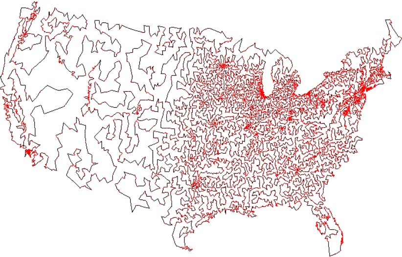

13,509 cities in the United States

- http://www.math.uwaterloo.ca/tsp

## HAM-CYCLE $\le_P$ TSP

**TSP**. Given a set of $n$ cities and a pairwise distance function $d(u, v)$, is there a tour of length $\le D$ ?

**HAM-CYCLE**. Given an undirected graph $G = (V, E)$, does there exist a cycle that visits every node exactly once?

**Theorem**. HAM-CYCLE $\le_P$ TSP.  
**Pf**.

- Given an instance $G = (V, E)$ of HAM-CYCLE, create $n = |V|$ cities with distance function

$$d(u, v) = \left\{ \begin{array}{ll}
1 & \text{if}\ (u, v) \in E \\
2 & \text{if}\ (u, v) \notin E \\
\end{array}\right.$$

- TSP instance has tour of length $\le n$ iff $G$ has a Hamilton cycle.

## Exponential algorithm for TSP: DP

**Theorem**. [Held-Karp, Bellman 1962] TSP can be solved in $O(n^2 2^n)$ time.  
**Pf**. [dynamic programming]

- Subproblems: $c(s, v, X)$ = cost of cheapest path between $s$ and $v \ne s$ that visits every node in $X$ exactly once (and uses only nodes in $X$).
- Goal: $\min_{v \in V} c(s, v, V) + c(v, s)$
- There are $\le n 2^n$ subproblems and they satisfy the recurrence:

$$c(s, v, X) = \left\{ \begin{array}{ll}
c(v, s) & \text{if}\ |X| = 2 \\
\min_{u \in X\backslash\{s,v\}} c(s,u,X\backslash\{v\}) + c(u,v) &
\text{if}\ |X| > 2 \\
\end{array}\right.$$

- The values $c(s, v, X)$ can be computed in increasing order of the cardinality of $X$.

**Remark**. 22-city TSP instance takes 1,000 years!

## Concorde TSP solver

**Concorde TSP solver**. [Applegate-Bixby-Chvátal-Cook]

- Linear programming + branch-and-bound + polyhedral combinatorics.
- Greedy heuristics, including Lin-Kernighan.
- MST, Delaunay triangulations, fractional b-matchings, etc.

**Remarkable fact**. Concorde has solved all 110 TSPLIB instances.

- largest instance has 85,900 cities!

## Euclidean TSP

**Euclidean TSP**. Given $n$ points in the plane and a real number $L$, is there a tour that visit every city exactly once that has distance $\le L$?

**Fact**. 3-SAT $\le_P$ EUCLIDEAN-TSP.

**Remark**. Not known to be in $\mathcal{NP}$.

**Theorem**. [Arora 1998, Mitchell 1999] Given $n$ points in the plane, for any constant $\epsilon > 0$: there exists a poly-time algorithm to find a tour whose length is at most $(1 + \epsilon)$ times that of the optimal tour.  
**Pf recipe**. Structure theorem + divide-and-conquer + dynamic programming.